# Week1: Linear Models

### f) Try a few different transformations of the variables, such as `log(X)`, `sqrt(X)`, $X^2$. Comment on your findings.

```python
# BEGIN SOLUTION

import numpy as np

#Logarithmic Transformation log(X):
df['log_horsepower'] = np.log(df['horsepower'])
df['log_weight'] = np.log(df['weight'])
df['log_acceleration'] = np.log(df['acceleration'])

model_log = sm.OLS(y, sm.add_constant(df[['log_horsepower', 'log_weight', 'log_acceleration']])).fit()

print("log(X) Summary")
print(model_log.summary())

#Square Root Transformation sqrt(X):
df['sqrt_horsepower'] = np.sqrt(df['horsepower'])
df['sqrt_weight'] = np.sqrt(df['weight'])
df['sqrt_acceleration'] = np.sqrt(df['acceleration'])

model_sqrt = sm.OLS(y, sm.add_constant(df[['sqrt_horsepower', 'sqrt_weight', 'sqrt_acceleration']])).fit()
print("sqrt(X) Summary")
print(model_sqrt.summary())


#Squared Transformation (X^2):
df['horsepower_sq'] = df['horsepower'] ** 2
df['weight_sq'] = df['weight'] ** 2
df['acceleration_sq'] = df['acceleration'] ** 2


model_sq = sm.OLS(y, sm.add_constant(df[['horsepower_sq', 'weight_sq', 'acceleration_sq']])).fit()

print("X^2 Summary")
print(model_sq.summary())


# END SOLUTION
```

```
log(X) Summary
                            OLS Regression Results
==============================================================================
Dep. Variable:                    mpg   R-squared:                       0.739
Model:                            OLS   Adj. R-squared:                  0.737
Method:                 Least Squares   F-statistic:                     370.5
Date:                Tue, 26 Mar 2024   Prob (F-statistic):          3.83e-114
Time:                        18:19:21   Log-Likelihood:                -1113.2
No. Observations:                 397   AIC:                             2234.
Df Residuals:                     393   BIC:                             2250.
Df Model:                           3
Covariance Type:            nonrobust
====================================================================================
                       coef    std err          t      P>|t|      [0.025      0.975]
------------------------------------------------------------------------------------
const              192.1851      8.349     23.019      0.000     175.771     208.600
log_horsepower      -9.9476      1.827     -5.446      0.000     -13.539      -6.356
log_weight         -14.1096      1.721     -8.198      0.000     -17.493     -10.726
log_acceleration    -3.9421      1.904     -2.071      0.039      -7.685      -0.200
==============================================================================
Omnibus:                       35.826   Durbin-Watson:                   0.921
Prob(Omnibus):                  0.000   Jarque-Bera (JB):               52.108
Skew:                           0.631   Prob(JB):                     4.84e-12
Kurtosis:                       4.247   Cond. No.                         403.
==============================================================================

Notes:
[1] Standard Errors assume that the covariance matrix of the errors is correctly specified.
sqrt(X) Summary
                            OLS Regression Results
==============================================================================
Dep. Variable:                    mpg   R-squared:                       0.724
Model:                            OLS   Adj. R-squared:                  0.722
Method:                 Least Squares   F-statistic:                     343.4
Date:                Tue, 26 Mar 2024   Prob (F-statistic):          2.06e-109
Time:                        18:19:21   Log-Likelihood:                -1124.2
No. Observations:                 397   AIC:                             2256.
Df Residuals:                     393   BIC:                             2272.
Df Model:                           3
Covariance Type:            nonrobust
```

[output cut: 33 more lines]

```
const              32.1081      1.107     29.011      0.000      29.932      34.284
horsepower_sq   -3.341e-05   5.08e-05     -0.657      0.512      -0.000    6.66e-05
weight_sq       -1.057e-06   7.86e-08    -13.438      0.000   -1.21e-06   -9.02e-07
acceleration_sq     0.0076      0.003      2.249      0.025       0.001       0.014
==============================================================================
Omnibus:                       26.148   Durbin-Watson:                   0.828
Prob(Omnibus):                  0.000   Jarque-Bera (JB):               29.544
Skew:                           0.624   Prob(JB):                     3.84e-07
Kurtosis:                       3.476   Cond. No.                     5.28e+07
==============================================================================

Notes:
[1] Standard Errors assume that the covariance matrix of the errors is correctly specified.
[2] The condition number is large, 5.28e+07. This might indicate that there are
strong multicollinearity or other numerical problems.
```

The logarithmic transformation is the most effective in improving the model fit

Whereas the squared transformation had the least positive effect.

The choice of transformation depends on the data and modeling goals.

## Question 6

In this exercise you will create some simulated data and will fit simple linear regression models to it. Make sure to use `set.seed(1)` prior to starting part (a) to ensure consistent results.

### a) Using the random normal function, create a vector, `x`, containing 100 observations drawn from a $N(0, 1)$ distribution. This represents a feature, `X`.

Link to random normal function: https://numpy.org/doc/stable/reference/random/generated/numpy.random.normal.html

```python
# BEGIN SOLUTION

np.random.seed(1)
x = np.random.normal(0, 1, 100)
x

# END SOLUTION
```

```
array([ 1.62434536, -0.61175641, -0.52817175, -1.07296862,  0.86540763,
       -2.3015387 ,  1.74481176, -0.7612069 ,  0.3190391 , -0.24937038,
        1.46210794, -2.06014071, -0.3224172 , -0.38405435,  1.13376944,
       -1.09989127, -0.17242821, -0.87785842,  0.04221375,  0.58281521,
       -1.10061918,  1.14472371,  0.90159072,  0.50249434,  0.90085595,
       -0.68372786, -0.12289023, -0.93576943, -0.26788808,  0.53035547,
       -0.69166075, -0.39675353, -0.6871727 , -0.84520564, -0.67124613,
       -0.0126646 , -1.11731035,  0.2344157 ,  1.65980218,  0.74204416,
       -0.19183555, -0.88762896, -0.74715829,  1.6924546 ,  0.05080775,
       -0.63699565,  0.19091548,  2.10025514,  0.12015895,  0.61720311,
        0.30017032, -0.35224985, -1.1425182 , -0.34934272, -0.20889423,
        0.58662319,  0.83898341,  0.93110208,  0.28558733,  0.88514116,
       -0.75439794,  1.25286816,  0.51292982, -0.29809284,  0.48851815,
       -0.07557171,  1.13162939,  1.51981682,  2.18557541, -1.39649634,
       -1.44411381, -0.50446586,  0.16003707,  0.87616892,  0.31563495,
       -2.02220122, -0.30620401,  0.82797464,  0.23009474,  0.76201118,
       -0.22232814, -0.20075807,  0.18656139,  0.41005165,  0.19829972,
        0.11900865, -0.67066229,  0.37756379,  0.12182127,  1.12948391,
        1.19891788,  0.18515642, -0.37528495, -0.63873041,  0.42349435,
        0.07734007, -0.34385368,  0.04359686, -0.62000084,  0.69803203])
```

### b) Using the `random normal` function, create a vector, `eps`, containing 100 observations drawn from a $N(0, 0.25)$ distribution — a normal distribution with mean zero and variance `0.25`.

Link to random normal function: https://numpy.org/doc/stable/reference/random/generated/numpy.random.normal.html

```python
# BEGIN SOLUTION

eps = np.random.normal(0, 0.25, 100)
eps

# END SOLUTION
```

```
array([-0.11178214,  0.30612693,  0.10087291,  0.14839463, -0.27372796,
        0.04234561,  0.18513911, -0.23842515, -0.06655463,  0.00815364,
       -0.34327933,  0.07878985,  0.21154016, -0.21487899,  0.08763649,
       -0.32807085, -0.00967388, -0.40394309,  0.28035443,  0.10222513,
       -0.00615424, -0.1937904 ,  0.31843898,  0.49177544, -0.46449547,
        0.30904101,  0.40691269,  0.08450292, -0.29981701,  0.21583633,
       -0.04523008, -0.15098016, -0.30751453,  0.13763437,  0.19820172,
       -0.15588268,  0.13014408, -0.28608535,  0.20046526,  0.01164182,
       -0.04664244, -0.02543647,  0.21722154,  0.18760291,  0.13236633,
        0.0344253 ,  0.01945528,  0.15459507,  0.05812364,  0.17063785,
       -0.07752919, -0.60870944,  0.25970615,  0.54674491,  0.11034111,
       -0.02503881, -0.03411119, -0.02976355,  0.00435235, -0.28050468,
       -0.12927361, -0.24925671,  0.06219979, -0.07416029,  0.12380283,
       -0.04367579,  0.2465838 ,  0.05338348,  0.54767493, -0.47409023,
       -0.16172917,  0.22537172,  0.63208143, -0.06215869,  0.01091725,
       -0.05657856,  0.33286428, -0.07182697,  0.17001746, -0.0799504 ,
       -0.31813969,  0.07838693,  0.1257962 ,  0.32330647, -0.02761176,
       -0.15434052,  0.14069027,  0.06018427,  0.07016627, -0.01827818,
        0.29008464,  0.09237318,  0.47616468,  0.27776417,  0.16476245,
       -0.40685959,  0.15057982,  0.10507055,  0.20273792,  0.26111052])
```

### c) Using `x` and `eps`, generate a vector `y` according to the model $Y = -1 + 0.5X + ϵ$. What is the length of the vector `y`? What are the values of $β_0$ and $β_1$ in this linear model?

```python
# BEGIN SOLUTION
y = -1 + 0.5 * x + eps

length_y = len(y)
print("Length of y:", length_y)
# END SOLUTION
```

```
Length of y: 100
```

beta0 = -1

beta1 = 0.5

### d) Create a scatterplot displaying the relationship between `x` and `y`. Comment on what you observe.

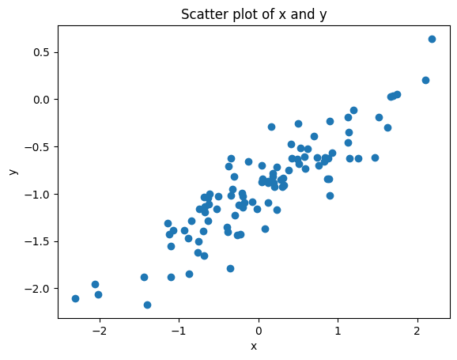

```python
# BEGIN SOLUTION

plt.scatter(x, y)
plt.xlabel('x')
plt.ylabel('y')
plt.title('Scatter plot of x and y')
plt.show()


# END SOLUTION
```

The scatterplot reveals a clear positive linear relationship between the variables x and y.

x values increase, y values tend to increase as well showing a positive correlation.

The plot aligns with a line having a positive slope and a negative intercept, following the linear model Y = -1 + 0.5X + eps.

While there is some variability due to random noise, no extreme outliers are evident.

The data appears to have a relatively constant spread across different x values, indicating a constant variance.

### e) Fit a least squares linear model that relates y and `x`. Comment on the model obtained. How do the estimated coefficients (slope and intercept) compare to the true values used to simulate the data?

```python
# BEGIN SOLUTION

X = sm.add_constant(x)

model1 = sm.OLS(y, X).fit()

model_summary = model1.summary()

print("model1 summary")
print(model_summary)


# END SOLUTION
```

```
model1 summary
                            OLS Regression Results
==============================================================================
Dep. Variable:                      y   R-squared:                       0.800
Model:                            OLS   Adj. R-squared:                  0.798
Method:                 Least Squares   F-statistic:                     391.4
Date:                Tue, 26 Mar 2024   Prob (F-statistic):           5.39e-36
Time:                        18:21:24   Log-Likelihood:                 4.1908
No. Observations:                 100   AIC:                            -4.382
Df Residuals:                      98   BIC:                            0.8288
Df Model:                           1
Covariance Type:            nonrobust
==============================================================================
                 coef    std err          t      P>|t|      [0.025      0.975]
------------------------------------------------------------------------------
const         -0.9632      0.023    -40.999      0.000      -1.010      -0.917
x1             0.5239      0.026     19.783      0.000       0.471       0.576
==============================================================================
Omnibus:                        0.898   Durbin-Watson:                   2.157
Prob(Omnibus):                  0.638   Jarque-Bera (JB):                0.561
Skew:                          -0.172   Prob(JB):                        0.755
Kurtosis:                       3.127   Cond. No.                         1.15
==============================================================================

Notes:
[1] Standard Errors assume that the covariance matrix of the errors is correctly specified.
```

The R-squared value in the summary is 0.800, indicate approximately 80% of the variance in the dependent variable (y) is explained by the independent variable (x).

The intercept (const) is approximately -0.9632, and the slope (x1) is approximately 0.5239.

The values are close to the true values used to simulate the data which were -1 and 0.5.

This suggests that the model accurately captures the relationship between x and y.

The F-statistic is 391.4 and its associated p-value is close to zero indicating that the overall model is statistically significant.

### f) Display the least squares line on the scatterplot obtained in (d). Draw the estimated regression line on the plot, in a different color. Feel free to use any framework such as ggplot or matplotlib, seaborn etc

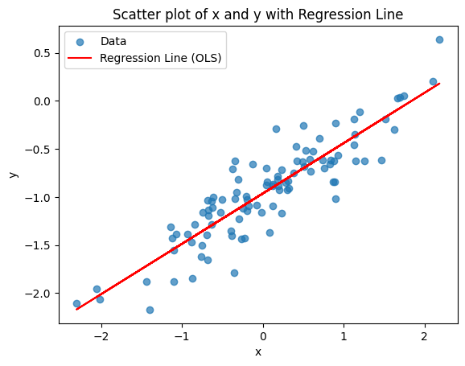

```python
# BEGIN SOLUTION

plt.scatter(x, y, label='Data', alpha=0.7)

y_pred = model1.predict(X)

plt.plot(x, y_pred, color='red', label='Regression Line (OLS)')

plt.xlabel('x')
plt.ylabel('y')
plt.title('Scatter plot of x and y with Regression Line')
plt.legend()
plt.show()

# END SOLUTION
```

The scatterplot showing the relationship between two variables, x and y.

The red line, which is the least squares regression line that best fits the data, indicating the general trend or relationship between the variables.

This line suggests that as x increases y is expected to increase reflecting a positive correlation between the two.

The statistical measures like the R-squared value from the regression analysis, which assesses how well the line fits the data.

### g) Now fit a polynomial regression model that predicts $y$ using $x$ and $x^2$. Is there evidence that the quadratic term improves the model fit? Explain your answer.

```python
# BEGIN SOLUTION

#Creating a new DataFrame with x and x^2
df_poly = pd.DataFrame({'x': x, 'x^2': x**2})

model_polynomial = sm.OLS(y, sm.add_constant(df_poly)).fit()

model_polynomial_summary = model_polynomial.summary()

print(model_polynomial_summary)

# END SOLUTION
```

```
                            OLS Regression Results
==============================================================================
Dep. Variable:                      y   R-squared:                       0.800
Model:                            OLS   Adj. R-squared:                  0.796
Method:                 Least Squares   F-statistic:                     193.8
Date:                Tue, 26 Mar 2024   Prob (F-statistic):           1.32e-34
Time:                        18:22:08   Log-Likelihood:                 4.2077
No. Observations:                 100   AIC:                            -2.415
Df Residuals:                      97   BIC:                             5.400
Df Model:                           2
Covariance Type:            nonrobust
==============================================================================
                 coef    std err          t      P>|t|      [0.025      0.975]
------------------------------------------------------------------------------
const         -0.9663      0.029    -33.486      0.000      -1.024      -0.909
x              0.5234      0.027     19.582      0.000       0.470       0.576
x^2            0.0039      0.021      0.181      0.856      -0.038       0.046
==============================================================================
Omnibus:                        0.893   Durbin-Watson:                   2.152
Prob(Omnibus):                  0.640   Jarque-Bera (JB):                0.552
Skew:                          -0.170   Prob(JB):                        0.759
Kurtosis:                       3.132   Cond. No.                         2.10
==============================================================================

Notes:
[1] Standard Errors assume that the covariance matrix of the errors is correctly specified.
```

The summary of the polynomial regression model suggests it's a good fit for the data.

### h) Repeat (a)–(f) after modifying the data generation process in such a way that there is less noise in the data. The model analyzed in this section,, should remain the same. You can do this by decreasing the variance of the normal distribution used to generate the error term ϵ in (b). Describe your results.

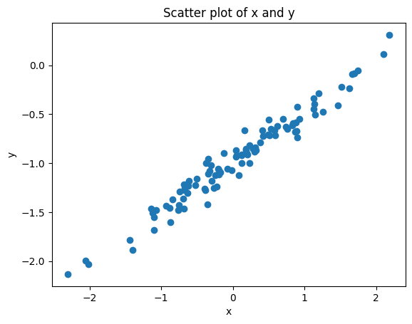

```
                            OLS Regression Results
==============================================================================
Dep. Variable:                      y   R-squared:                       0.959
Model:                            OLS   Adj. R-squared:                  0.959
Method:                 Least Squares   F-statistic:                     2314.
Date:                Tue, 26 Mar 2024   Prob (F-statistic):           5.58e-70
Time:                        18:22:32   Log-Likelihood:                 95.820
No. Observations:                 100   AIC:                            -187.6
Df Residuals:                      98   BIC:                            -182.4
Df Model:                           1
Covariance Type:            nonrobust
==============================================================================
                 coef    std err          t      P>|t|      [0.025      0.975]
------------------------------------------------------------------------------
const         -0.9853      0.009   -104.844      0.000      -1.004      -0.967
x1             0.5095      0.011     48.105      0.000       0.489       0.531
==============================================================================
Omnibus:                        0.898   Durbin-Watson:                   2.157
Prob(Omnibus):                  0.638   Jarque-Bera (JB):                0.561
Skew:                          -0.172   Prob(JB):                        0.755
Kurtosis:                       3.127   Cond. No.                         1.15
==============================================================================

Notes:
[1] Standard Errors assume that the covariance matrix of the errors is correctly specified.
```

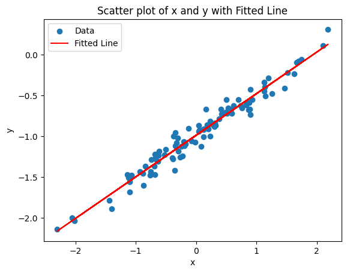

```python
# BEGIN SOLUTION
np.random.seed(1)
x = np.random.normal(0, 1, 100)

eps2 = np.random.normal(0, 0.1, 100)

y = -1 + 0.5 * x + eps2

length_y = len(y)

plt.scatter(x, y)
plt.xlabel('x')
plt.ylabel('y')
plt.title('Scatter plot of x and y')
plt.show()

X = sm.add_constant(x)
model2 = sm.OLS(y, X).fit()

model_summary = model2.summary()
print(model_summary)

plt.scatter(x, y, label='Data')
plt.plot(x, model2.fittedvalues, color='red', label='Fitted Line')
plt.xlabel('x')
plt.ylabel('y')
plt.legend()
plt.title('Scatter plot of x and y with Fitted Line')
plt.show()

# END SOLUTION
```

The linear regression model fits the data very well with a high R-squared value of 0.959 indicating that the model explains most of the variability in the data.

The coefficients of the model closely match the true values used to generate the data, and both the intercept and the slope are statistically significant (p-values close to 0).

This means that the model accurately captures the relationship between x and y, with minimal noise.

The scatterplot and the fitted line demonstrate this strong relationship.